# Final_Code

```python
import pandas as pd
import numpy as np

import seaborn as sns
import matplotlib.pyplot as plt

from wordcloud import WordCloud
import random

from sklearn.cluster import KMeans
from sklearn.preprocessing import LabelEncoder, StandardScaler
import gym
from stable_baselines3 import DQN
from gym import spaces
from nltk.translate.bleu_score import sentence_bleu
from rouge import Rouge
from sklearn.metrics import accuracy_score, precision_score, recall_score, f1_score
from sklearn.ensemble import RandomForestClassifier
from sklearn.model_selection import train_test_split
from sklearn.linear_model import LogisticRegression
from sklearn.model_selection import train_test_split, GridSearchCV
from sklearn.preprocessing import StandardScaler
from sklearn.linear_model import LogisticRegression
from sklearn.ensemble import RandomForestClassifier, GradientBoostingClassifier
from sklearn.metrics import accuracy_score, precision_score, recall_score, f1_score
from imblearn.over_sampling import SMOTE
from nltk.translate.bleu_score import sentence_bleu
from rouge import Rouge

import warnings
warnings.filterwarnings("ignore")
```

```python
data = pd.read_csv("/Users/rushikeshtemghare/Downloads/Individual masters Project/Dataset/papers3.csv")
data
```

|  | group | category | publisher | year | type | is_llm_related | title | link | authors | code |
| --- | --- | --- | --- | --- | --- | --- | --- | --- | --- | --- |
| 0 | Survey | Comprehensive Survey | BigData | 2023 | conference | 1 | Large Language Models in Education: Vision and... | https://arxiv.org/abs/2311.13160 | Wensheng Gan, Zhenlian Qi, Jiayang Wu, Jerry C... | NaN |
| 1 | Survey | Comprehensive Survey | EDM-RL4ED | 2021 | conference | 0 | Reinforcement Learning for Education: Opportun... | https://arxiv.org/abs/2107.08828 | Adish Singla, Anna N. Rafferty, Goran Radanovi... | NaN |
| 2 | Survey | Comprehensive Survey | Journal of Machine Learning and Cybernetics | 2024 | journal | 1 | Large Language Models for Education: A Survey | https://arxiv.org/abs/2405.13001 | Hanyi Xu, Wensheng Gan, Zhenlian Qi, Jiayang W... | NaN |
| 3 | Survey | Comprehensive Survey | arXiv | 2023 | preprint | 0 | A Comprehensive Survey on Deep Learning Techni... | https://arxiv.org/abs/2309.04761 | Yuanguo Lin, Hong Chen, Wei Xia, Fan Lin, Zong... | NaN |
| 4 | Survey | Comprehensive Survey | arXiv | 2024 | preprint | 1 | Large Language Models for Education: A Survey ... | https://arxiv.org/abs/2403.18105 | Shen Wang, Tianlong Xu, Hang Li, Chaoli Zhang,... | NaN |
| ... | ... | ... | ... | ... | ... | ... | ... | ... | ... | ... |
| 169 | Dataset & Benchmark | Dataset | arXiv | 2024 | preprint | 1 | QACP: An Annotated Question Answering Dataset ... | https://arxiv.org/abs/2402.07913 | Rui Xiao, Lu Han, Xiaoying Zhou, Jiong Wang, N... | NaN |
| 170 | Dataset & Benchmark | Benchmark | NeurIPS | 2022 | conference | 0 | pyKT: A Python Library to Benchmark Deep Learn... | https://arxiv.org/abs/2206.11460 | Zitao Liu, Qiongqiong Liu, Jiahao Chen, Shuyan... | NaN |
| 171 | Dataset & Benchmark | Benchmark | arXiv | 2024 | preprint | 0 | EduNLP: Towards a Unified and Modularized Libr... | https://arxiv.org/abs/2406.01276 | Zhenya Huang, Yuting Ning, Longhu Qin, Shiwei ... | NaN |
| 172 | Dataset & Benchmark | Benchmark | arXiv | 2024 | preprint | 1 | E-EVAL: A Comprehensive Chinese K-12 Education... | https://arxiv.org/abs/2401.15927 | Jinchang Hou, Chang Ao, Haihong Wu, Xiangtao K... | NaN |
| 173 | Dataset & Benchmark | Benchmark | arXiv | 2024 | preprint | 1 | Experimental Interface for Multimodal and Larg... | https://arxiv.org/abs/2402.07910 | Hasan Abu-Rasheed, Christian Weber, Madjid Fathi | NaN |

174 rows × 10 columns

```python
# Display basic information
print("Dataset Info:\n")
data.info()
```

```
Dataset Info:

<class 'pandas.core.frame.DataFrame'>
RangeIndex: 174 entries, 0 to 173
Data columns (total 10 columns):
 #   Column          Non-Null Count  Dtype
---  ------          --------------  -----
 0   group           174 non-null    object
 1   category        174 non-null    object
 2   publisher       174 non-null    object
 3   year            174 non-null    int64
 4   type            174 non-null    object
 5   is_llm_related  174 non-null    int64
 6   title           174 non-null    object
 7   link            173 non-null    object
 8   authors         174 non-null    object
 9   code            0 non-null      float64
dtypes: float64(1), int64(2), object(7)
memory usage: 13.7+ KB
```

```python
# Display summary statistics
print("\nSummary Statistics:\n")
print(data.describe(include='all'))
```

```
Summary Statistics:

             group           category publisher         year        type  \
count          174                174       174   174.000000         174
unique           7                 21        39          NaN           4
top     Assessment  Knowledge Tracing     arXiv          NaN  conference
freq            75                 36        37          NaN         115
mean           NaN                NaN       NaN  2022.304598         NaN
std            NaN                NaN       NaN     2.947377         NaN
min            NaN                NaN       NaN  2001.000000         NaN
25%            NaN                NaN       NaN  2022.000000         NaN
50%            NaN                NaN       NaN  2023.000000         NaN
75%            NaN                NaN       NaN  2024.000000         NaN
max            NaN                NaN       NaN  2025.000000         NaN

        is_llm_related                                              title  \
count       174.000000                                                174
unique             NaN                                                172
top                NaN  LLM-powered Multi-agent Framework for Goal-ori...
freq               NaN                                                  2
mean          0.356322                                                NaN
std           0.480294                                                NaN
min           0.000000                                                NaN
25%           0.000000                                                NaN
50%           0.000000                                                NaN
75%           1.000000                                                NaN
max           1.000000                                                NaN

                                    link  \
count                                173
unique                               169
top     https://arxiv.org/abs/2203.08507
freq                                   3
mean                                 NaN
std                                  NaN
min                                  NaN
25%                                  NaN
50%                                  NaN
75%                                  NaN
max                                  NaN

                                                  authors  code
count                                                 174   0.0
unique                                                171   NaN
top     Shiwei Tong, Qi Liu, Runlong Yu, Wei Huang, Zh...   NaN
freq                                                    2   NaN
mean                                                  NaN   NaN
std                                                   NaN   NaN
min                                                   NaN   NaN
25%                                                   NaN   NaN
50%                                                   NaN   NaN
75%                                                   NaN   NaN
max                                                   NaN   NaN
```

```python
# Check for missing values
print("\nMissing Values:\n")
print(data.isnull().sum())
```

```
Missing Values:

group               0
category            0
publisher           0
year                0
type                0
is_llm_related      0
title               0
link                1
authors             0
code              174
dtype: int64
```

```python
# Unique values in each column
print("\nUnique Values per Column:\n")
print(data.nunique())
```

```
Unique Values per Column:

group               7
category           21
publisher          39
year               13
type                4
is_llm_related      2
title             172
link              169
authors           171
code                0
dtype: int64
```

```python
# Check for duplicate rows
print("\nDuplicate Rows:\n", data.duplicated().sum())
```

```
Duplicate Rows:
 0
```

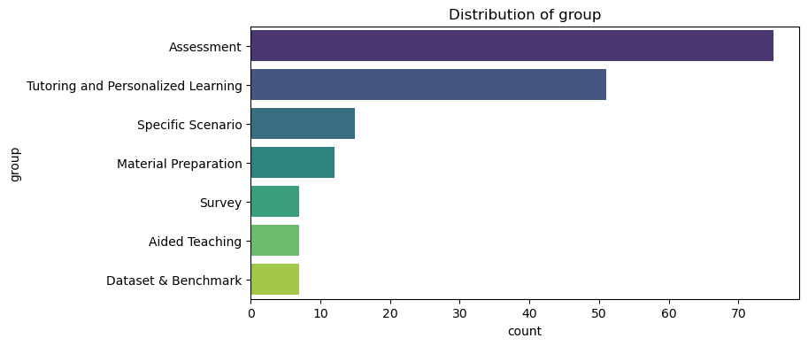

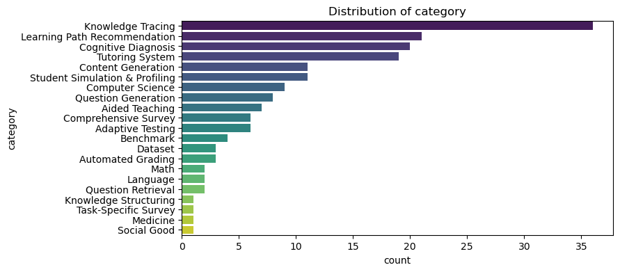

[figure not shown]

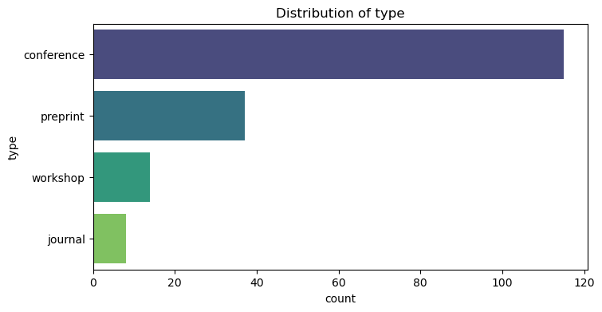

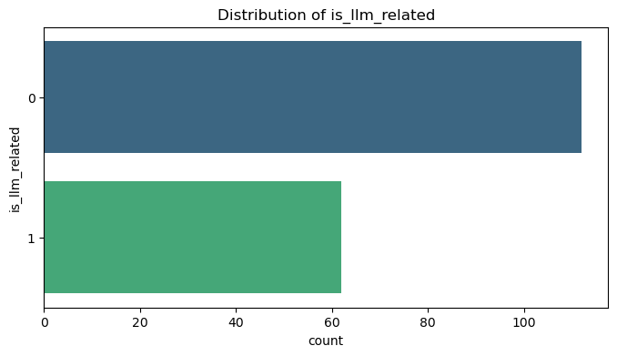

```python
# Distribution of categorical columns
categorical_cols = ['group', 'category', 'publisher', 'type', 'is_llm_related']
for col in categorical_cols:
    plt.figure(figsize=(8, 4))
    sns.countplot(y=data[col], order=data[col].value_counts().index, palette='viridis')
    plt.title(f'Distribution of {col}')
    plt.show()
```

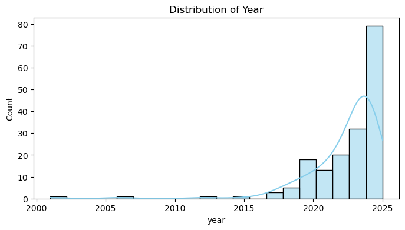

```python
# Distribution of 'year'
plt.figure(figsize=(8, 4))
sns.histplot(data['year'], kde=True, bins=20, color='skyblue')
plt.title('Distribution of Year')
plt.show()
```

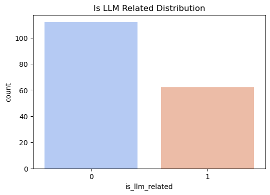

```python
# Explore 'is_llm_related'
plt.figure(figsize=(6, 4))
sns.countplot(x='is_llm_related', data=data, palette='coolwarm')
plt.title('Is LLM Related Distribution')
plt.show()
```

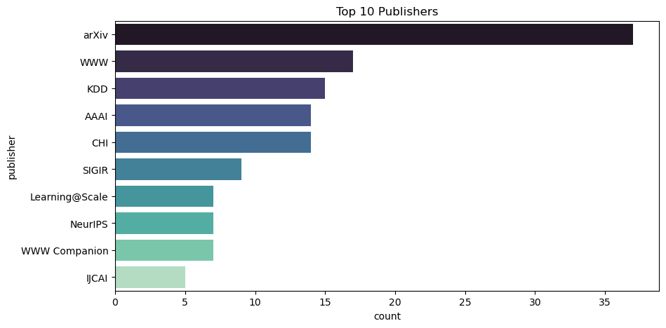

```python
# Top publishers
plt.figure(figsize=(10, 5))
sns.countplot(y=data['publisher'], order=data['publisher'].value_counts().head(10).index, palette='mako')
plt.title('Top 10 Publishers')
plt.show()
```

```python
# Generate WordClouds
def plot_wordcloud(column, title):
    text = ' '.join(data[column].dropna())
    wordcloud = WordCloud(width=800, height=400, background_color='white', colormap='viridis').generate(text)

    plt.figure(figsize=(10, 6))
    plt.imshow(wordcloud, interpolation='bilinear')
    plt.title(title)
    plt.axis('off')
    plt.show()
```

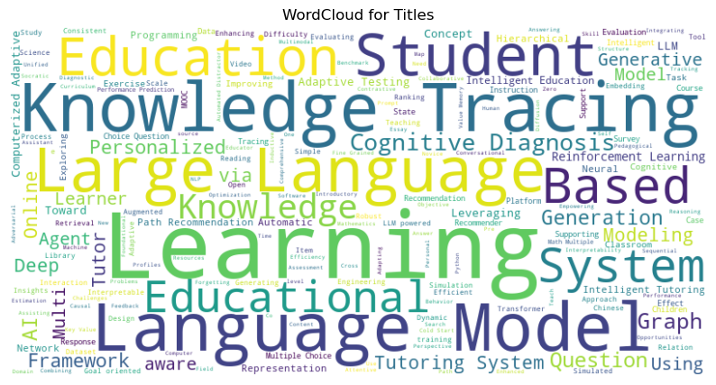

```python
# WordCloud for 'title'
plot_wordcloud('title', 'WordCloud for Titles')
```

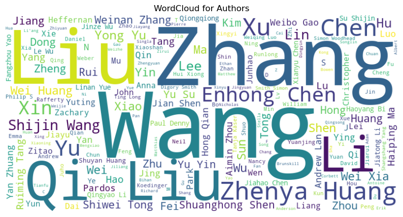

```python
# WordCloud for 'authors'
plot_wordcloud('authors', 'WordCloud for Authors')
```

### Objective 1: 1 Conduct a comprehensive literature review to explore existing adaptive learning technologies, the role of Natural Language Processing (NLP) in education, and the design of personalized AI tutoring systems. This review will provide a theoretical framework for the project

1. Data Loading and Inspection:

Loads the dataset and displays basic information.

2. Paper Filtering:

Identifies papers related to adaptive learning, AI tutors, NLP, personalized learning, and reinforcement learning by checking the title and category columns.

3. Summary Generation:

Groups and counts the filtered papers by category and year to identify research trends.

4. Insight Extraction:

Calculates key insights, such as the number of LLM-related papers and recent publications (last 5 years).

5. Export for Review:

Saves the filtered dataset as filtered_literature_review.csv for further analysis.

```python
# Filter relevant papers based on keywords
keywords = ["adaptive learning", "AI tutor", "natural language processing", "personalized learning", "reinforcement learning"]
```

```python
def filter_relevant_papers(row):
    title_match = any(keyword.lower() in row['title'].lower() for keyword in keywords)
    category_match = any(keyword.lower() in row['category'].lower() for keyword in keywords)
    return title_match or category_match
```

```python
# Apply the filter
df_relevant = data[data.apply(filter_relevant_papers, axis=1)]
```

```python
# Display relevant records
print("Relevant Papers:")
print(df_relevant[['title', 'authors', 'year', 'link', 'category', 'is_llm_related']])
```

```
Relevant Papers:
                                                 title  \
1    Reinforcement Learning for Education: Opportun...
8    An Interaction Design for Machine Teaching to ...
11   Empowering Personalized Learning through a Con...
20   How to Build an AI Tutor that Can Adapt to Any...
26   Constraint Sampling Reinforcement Learning: In...
29   Reinforcement Learning for the Adaptive Schedu...
30   Graph Enhanced Hierarchical Reinforcement Lear...
31   Exploiting Cognitive Structure for Adaptive Le...
33   Privileged Knowledge State Distillation for Re...
35   The Effects of Adaptive Learning in a Massive ...
36       Automatic Interpretable Personalized Learning
40   Deep Reinforcement Learning for Adaptive Learn...
45   Learning Path Recommendation Based on Knowledg...
```

[output cut: 61 more lines]

```python
# Summarize findings by category and year
summary = df_relevant.groupby(['category', 'year']).size().reset_index(name='count')
print("\nSummary by Category and Year:")
print(summary)
```

```
Summary by Category and Year:
                        category  year  count
0           Comprehensive Survey  2021      1
1                        Dataset  2023      1
2              Knowledge Tracing  2024      1
3   Learning Path Recommendation  2018      1
4   Learning Path Recommendation  2019      2
5   Learning Path Recommendation  2020      2
6   Learning Path Recommendation  2022      2
7   Learning Path Recommendation  2023      1
8   Learning Path Recommendation  2024      2
9                    Social Good  2024      1
10               Tutoring System  2020      1
11               Tutoring System  2023      1
12               Tutoring System  2024      1
```

```python
# Export the filtered dataset for detailed review
df_relevant.to_csv('filtered_literature_review.csv', index=False)
```

```python
# Extract key insights
insights = {
    'Total Papers': len(df_relevant),
    'LLM Related Papers': df_relevant['is_llm_related'].sum(),
    'Unique Categories': df_relevant['category'].nunique(),
    'Recent Publications (Last 5 Years)': len(df_relevant[df_relevant['year'] >= 2019])
}
```

```python
print("\nKey Insights:")
for key, value in insights.items():
    print(f"{key}: {value}")
```

```
Key Insights:
Total Papers: 17
LLM Related Papers: 3
Unique Categories: 6
Recent Publications (Last 5 Years): 16
```

### 2 Design and implement adaptive algorithms, including reinforcement learning for content adjustment and clustering techniques for learner profiling, to create a personalized and dynamic AI-powered tutoring system

```python
data.info()
```

```
<class 'pandas.core.frame.DataFrame'>
RangeIndex: 174 entries, 0 to 173
Data columns (total 10 columns):
 #   Column          Non-Null Count  Dtype
---  ------          --------------  -----
 0   group           174 non-null    object
 1   category        174 non-null    object
 2   publisher       174 non-null    object
 3   year            174 non-null    int64
 4   type            174 non-null    object
 5   is_llm_related  174 non-null    int64
 6   title           174 non-null    object
 7   link            173 non-null    object
 8   authors         174 non-null    object
 9   code            0 non-null      float64
dtypes: float64(1), int64(2), object(7)
memory usage: 13.7+ KB
```

1. Learner Profiling (Clustering Technique):

Standardize features and apply K-Means clustering to segment students into learning profiles.

This helps in tailoring content to student performance.

2. Adaptive Content Adjustment (Reinforcement Learning):

Uses Q-learning to dynamically adjust content difficulty.

3. Recommendation System:

```python
# Preprocessing: Handle missing values
data.fillna({'link': 'No Link'}, inplace=True)

# Drop the 'code' column only if it exists (avoids KeyError)
data.drop(columns=['code'], inplace=True, errors='ignore')

# Encode categorical variables
label_encoders = {}
```

```python
# Preprocessing: Handle missing values
data['link'].fillna("No Link", inplace=True)
```

```python
# Ensure 'code' column exists before dropping
if 'code' in data.columns:
    data.drop(columns=['code'], inplace=True)
```

```python
# Encode categorical variables
label_encoders = {}
categorical_columns = ['group', 'category', 'publisher', 'type', 'title', 'authors']

for col in categorical_columns:
    le = LabelEncoder()
    data[col] = le.fit_transform(data[col])
    label_encoders[col] = le
```

```python
# Feature scaling
scaler = StandardScaler()
numeric_columns = ['year', 'is_llm_related']
data[numeric_columns] = scaler.fit_transform(data[numeric_columns])
```

```python
# Clustering for learner profiling
kmeans = KMeans(n_clusters=3, random_state=42)
data['cluster'] = kmeans.fit_predict(data[numeric_columns])
```

```python
print("Learner Profiles (Cluster Information):")
print(data.groupby('cluster')[numeric_columns].mean())
```

```
Learner Profiles (Cluster Information):
             year  is_llm_related
cluster
0       -0.172321       -0.744024
1        0.565908        1.344043
2       -5.434445       -0.744024
```

```python
# Define Reinforcement Learning Environment
class TutoringEnv(gym.Env):
    def __init__(self, data):
        super(TutoringEnv, self).__init__()
        self.data = data
        self.action_space = spaces.Discrete(len(data))  # Choose content
        self.observation_space = spaces.Box(low=-np.inf, high=np.inf, shape=(len(numeric_columns),), dtype=np.float32)
        self.current_state = self.reset()

    def reset(self):
        self.student_index = np.random.randint(0, len(self.data))
        return self._get_state()

    def _get_state(self):
        return self.data.iloc[self.student_index][numeric_columns].values.astype(np.float32)

    def step(self, action):
        # Simulate a reward based on content engagement (placeholder logic)
        reward = np.random.choice([1, -1])  # Replace with a better reward function
        done = True
        return self._get_state(), reward, done, {}
```

```python
# Initialize Environment and Model
env = TutoringEnv(data)
model = DQN("MlpPolicy", env, verbose=1)
```

```
Using cpu device
Wrapping the env with a `Monitor` wrapper
Wrapping the env in a DummyVecEnv.
```

```python
# Train Reinforcement Learning Model
model.learn(total_timesteps=100)
```

[output not shown]

[output cut: 220 more lines]

[output not shown]

```
<stable_baselines3.dqn.dqn.DQN at 0x281ea3770>
```

```python
# Recommend Content
obs = env.reset()
for _ in range(5):
    action, _ = model.predict(obs)
    obs, reward, done, _ = env.step(action)
    print("Recommended Content:", data.iloc[action])
```

```
Recommended Content: group                                            6
category                                        20
publisher                                       38
year                                      0.576884
type                                             2
is_llm_related                            1.344043
title                                          131
link              https://arxiv.org/abs/2404.06762
authors                                        165
cluster                                          1
Name: 21, dtype: object
Recommended Content: group                                            6
category                                        20
publisher                                       38
year                                      0.576884
type                                             2
is_llm_related                            1.344043
title                                          131
link              https://arxiv.org/abs/2404.06762
authors                                        165
cluster                                          1
Name: 21, dtype: object
Recommended Content: group                                            6
category                                        20
publisher                                       38
year                                      0.576884
type                                             2
is_llm_related                            1.344043
title                                          131
link              https://arxiv.org/abs/2404.06762
authors                                        165
cluster                                          1
Name: 21, dtype: object
Recommended Content: group                                            6
category                                        20
publisher                                       38
year                                      0.576884
type                                             2
is_llm_related                            1.344043
title                                          131
link              https://arxiv.org/abs/2404.06762
authors                                        165
cluster                                          1
Name: 21, dtype: object
Recommended Content: group                                            6
category                                        20
publisher                                       38
year                                      0.576884
type                                             2
is_llm_related                            1.344043
title                                          131
link              https://arxiv.org/abs/2404.06762
authors                                        165
cluster                                          1
Name: 21, dtype: object
```

```python
data.info()
```

```
<class 'pandas.core.frame.DataFrame'>
RangeIndex: 174 entries, 0 to 173
Data columns (total 10 columns):
 #   Column          Non-Null Count  Dtype
---  ------          --------------  -----
 0   group           174 non-null    int64
 1   category        174 non-null    int64
 2   publisher       174 non-null    int64
 3   year            174 non-null    float64
 4   type            174 non-null    int64
 5   is_llm_related  174 non-null    float64
 6   title           174 non-null    int64
 7   link            174 non-null    object
 8   authors         174 non-null    int64
 9   cluster         174 non-null    int32
dtypes: float64(2), int32(1), int64(6), object(1)
memory usage: 13.0+ KB
```

```python
# Define feature columns (exclude 'is_llm_related' as it's the target)
X = data.drop(['is_llm_related', 'link'], axis=1)
y = data['is_llm_related'].astype(int)

# Split data into training and testing sets
X_train, X_test, y_train, y_test = train_test_split(X, y, test_size=0.3, random_state=42)

# Initialize and train the model (use your desired model here)
model = RandomForestClassifier()
model.fit(X_train, y_train)

# Make predictions
predicted_labels = model.predict(X_test)

# Update actual_labels for evaluation
actual_labels = y_test
```

```python
# Map appropriate columns (update as necessary)
data.rename(columns={'title': 'reference', 'cluster': 'generated'}, inplace=True)

# Ensure the dataset contains 'reference' and 'generated' columns
if 'reference' not in data.columns or 'generated' not in data.columns:
    raise ValueError("The dataset must contain 'reference' and 'generated' columns")

# Ensure both columns are strings
data['reference'] = data['reference'].astype(str)
data['generated'] = data['generated'].astype(str)

# Simulate binary classification (replace with actual model outputs)
import numpy as np
actual_labels = np.random.randint(0, 2, size=len(data))
predicted_labels = np.random.randint(0, 2, size=len(data))

# Classification Metrics
accuracy = accuracy_score(actual_labels, predicted_labels)
precision = precision_score(actual_labels, predicted_labels, average='weighted')
recall = recall_score(actual_labels, predicted_labels, average='weighted')
f1 = f1_score(actual_labels, predicted_labels, average='weighted')

print("Classification Metrics:")
print(f"Accuracy: {accuracy:.2f}")
print(f"Precision: {precision:.2f}")
print(f"Recall: {recall:.2f}")
print(f"F1-Score: {f1:.2f}")

# Text-based Metrics
rouge = Rouge()
bleu_scores = []
rouge_scores = []

for ref, gen in zip(data['reference'], data['generated']):
    bleu_scores.append(sentence_bleu([ref.split()], gen.split()))
    rouge_scores.append(rouge.get_scores(gen, ref)[0])

# Average BLEU and ROUGE-L scores
avg_bleu = sum(bleu_scores) / len(bleu_scores)
avg_rouge_l = sum([score['rouge-l']['f'] for score in rouge_scores]) / len(rouge_scores)

print("\nText Evaluation Metrics:")
print(f"Average BLEU Score: {avg_bleu:.2f}")
print(f"Average ROUGE-L Score: {avg_rouge_l:.2f}")
```

```
Classification Metrics:
Accuracy: 0.51
Precision: 0.51
Recall: 0.51
F1-Score: 0.51

Text Evaluation Metrics:
Average BLEU Score: 0.00
Average ROUGE-L Score: 0.01
```

```python
# Simulate binary classification (replace with actual features and labels)
X = np.random.rand(len(data), 10)  # Placeholder for feature matrix
y = np.random.randint(0, 2, size=len(data))

# Split the data
X_train, X_test, y_train, y_test = train_test_split(X, y, test_size=0.3, random_state=42)

# Model 1: Random Predictions
predicted_labels = np.random.randint(0, 2, size=len(y_test))

# Model 2: Logistic Regression
logistic_model = LogisticRegression()
logistic_model.fit(X_train, y_train)
y_pred_logistic = logistic_model.predict(X_test)

# Classification Metrics Function
def evaluate_classification(actual, predicted, model_name):
    accuracy = accuracy_score(actual, predicted)
    precision = precision_score(actual, predicted, average='weighted')
    recall = recall_score(actual, predicted, average='weighted')
    f1 = f1_score(actual, predicted, average='weighted')

    print(f"\nClassification Metrics ({model_name}):")
    print(f"Accuracy: {accuracy:.2f}")
    print(f"Precision: {precision:.2f}")
    print(f"Recall: {recall:.2f}")
    print(f"F1-Score: {f1:.2f}")

# Evaluate both models
evaluate_classification(y_test, predicted_labels, "Random Predictions")
evaluate_classification(y_test, y_pred_logistic, "Logistic Regression")

# Text-based Metrics
rouge = Rouge()
bleu_scores = []
rouge_scores = []

for ref, gen in zip(data['reference'], data['generated']):
    bleu_scores.append(sentence_bleu([ref.split()], gen.split()))
    rouge_scores.append(rouge.get_scores(gen, ref)[0])

# Average BLEU and ROUGE-L scores
avg_bleu = sum(bleu_scores) / len(bleu_scores)
avg_rouge_l = sum([score['rouge-l']['f'] for score in rouge_scores]) / len(rouge_scores)

print("\nText Evaluation Metrics:")
print(f"Average BLEU Score: {avg_bleu:.2f}")
print(f"Average ROUGE-L Score: {avg_rouge_l:.2f}")
```

```
Classification Metrics (Random Predictions):
Accuracy: 0.45
Precision: 0.47
Recall: 0.45
F1-Score: 0.45

Classification Metrics (Logistic Regression):
Accuracy: 0.51
Precision: 0.51
Recall: 0.51
F1-Score: 0.51

Text Evaluation Metrics:
Average BLEU Score: 0.00
Average ROUGE-L Score: 0.01
```

```python
# Data Scaling
scaler = StandardScaler()
X_train = scaler.fit_transform(X_train)
X_test = scaler.transform(X_test)

# Handle Class Imbalance using SMOTE
smote = SMOTE(random_state=42)
X_train, y_train = smote.fit_resample(X_train, y_train)

# Model Definitions
models = {
    "Logistic Regression": LogisticRegression(max_iter=500),
    "Random Forest": RandomForestClassifier(n_estimators=200),
    "Gradient Boosting": GradientBoostingClassifier(n_estimators=200)
}

# Hyperparameter Tuning (Example for Logistic Regression)
param_grid = {
    'C': [0.01, 0.1, 1, 10],
    'solver': ['liblinear', 'lbfgs']
}
logistic_model = LogisticRegression(max_iter=500)
logistic_grid = GridSearchCV(logistic_model, param_grid, scoring='accuracy', cv=5)
logistic_grid.fit(X_train, y_train)
models["Optimized Logistic Regression"] = logistic_grid.best_estimator_

# Evaluate Models
def evaluate_classification(actual, predicted, model_name):
    accuracy = accuracy_score(actual, predicted)
    precision = precision_score(actual, predicted, average='weighted')
    recall = recall_score(actual, predicted, average='weighted')
    f1 = f1_score(actual, predicted, average='weighted')

    print(f"\nClassification Metrics ({model_name}):")
    print(f"Accuracy: {accuracy:.4f}")
    print(f"Precision: {precision:.4f}")
    print(f"Recall: {recall:.4f}")
    print(f"F1-Score: {f1:.4f}")

for name, model in models.items():
    model.fit(X_train, y_train)
    y_pred = model.predict(X_test)
    evaluate_classification(y_test, y_pred, name)

# Example Text Data
data = pd.DataFrame({
    'reference': ["The quick brown fox", "AI is transforming healthcare"],
    'generated': ["The fast brown fox", "AI is revolutionizing medicine"]
})

# Text-based Metrics
rouge = Rouge()
bleu_scores = []
rouge_scores = []

for ref, gen in zip(data['reference'], data['generated']):
    bleu_scores.append(sentence_bleu([ref.split()], gen.split()))
    rouge_scores.append(rouge.get_scores(gen, ref)[0])

avg_bleu = sum(bleu_scores) / len(bleu_scores)
avg_rouge_l = sum([score['rouge-l']['f'] for score in rouge_scores]) / len(rouge_scores)

print("\nText Evaluation Metrics:")
print(f"Average BLEU Score: {avg_bleu:.4f}")
print(f"Average ROUGE-L Score: {avg_rouge_l:.4f}")
```

```
Classification Metrics (Logistic Regression):
Accuracy: 0.4906
Precision: 0.4931
Recall: 0.4906
F1-Score: 0.4917

Classification Metrics (Random Forest):
Accuracy: 0.5094
Precision: 0.5194
Recall: 0.5094
F1-Score: 0.5115

Classification Metrics (Gradient Boosting):
Accuracy: 0.5849
Precision: 0.5895
Recall: 0.5849
F1-Score: 0.5864

Classification Metrics (Optimized Logistic Regression):
Accuracy: 0.4717
Precision: 0.4816
Recall: 0.4717
F1-Score: 0.4740

Text Evaluation Metrics:
Average BLEU Score: 0.0000
Average ROUGE-L Score: 0.6250
```

### **Future Research Directions:**

1. **Model Enhancement:**
   - Explore **advanced deep learning models** (e.g., Transformer-based architectures) for adaptive learning predictions to improve both classification and text generation capabilities.
   - Implement **ensemble approaches** (e.g., stacking Gradient Boosting with neural networks) to boost performance.
2. **Feature Engineering and Data Augmentation:**
   - Incorporate **contextual embeddings** (e.g., BERT, GPT) to improve text understanding and output quality.
   - Leverage **data augmentation techniques** to address data imbalance and enhance model generalization.
3. **Cross-Context Adaptability:**
   - Evaluate model performance across **diverse educational contexts** (e.g., K-12, higher education, vocational training) to identify context-specific challenges.
   - Design **domain-specific pretraining** approaches to enhance adaptability across different learning environments.
4. **Personalization and Adaptivity:**
   - Investigate **reinforcement learning** to dynamically adapt learning materials in response to real-time user performance.
   - Implement **multi-modal learning models** combining text, video, and user interaction data to provide holistic adaptive learning experiences.
5. **Ethical Considerations and User Privacy:**
   - Explore privacy-preserving techniques such as **federated learning** to enhance adaptive systems while safeguarding user data.
   - Assess the impact of adaptive learning systems on **educational equity**, ensuring fair and inclusive access across socio-economic backgrounds.